# Covid_19 cases

W.G.

2023-08-17

# Analyzing the covid_19 data

## Introduction

This document aims to provide a comprehensive analysis of COVID-19 data compiled from various reputable sources, including the Johns Hopkins GitHub repository for case and fatality statistics, and the Oxford University GitHub repository for containment and health indices. Through the application of exploratory data analysis and data visualization techniques, our objective is to unveil meaningful insights and discern patterns inherent in the dataset.

# Importing Required Libraries

```r
library(tidyverse)
```

```r
library(lubridate)
library(ggplot2)
```

# Step 1: Data Import

## Saving Addresses

### Johns Hopkins GitHub URL and file names

```r
JH_url_in <- "https://raw.githubusercontent.com/CSSEGISandData/COVID-19/master/csse_covid_19_data/csse_covid_19_time_series/"

JH_file_names <- c(
"time_series_covid19_confirmed_global.csv",
"time_series_covid19_deaths_global.csv")

JH_URL <- str_c(JH_url_in, JH_file_names)

JH_UID <- "https://raw.githubusercontent.com/CSSEGISandData/COVID-19/master/csse_covid_19_data/UID_ISO_FIPS_LookUp_Table.csv"
```

### University of Oxford GitHub URL

the Containment Index includes containment and closure policies, and health system policies, but excludes vaccination

```r
OX_url_in <- "https://raw.githubusercontent.com/OxCGRT/covid-policy-dataset/main/data/timeseries_indices/OxCGRT_timeseries_ContainmentHealthIndex_v1.csv"
```

## Loading the Data

```r
global_cases <- read_csv(JH_URL[1])
global_deaths <- read_csv(JH_URL[2])
UID <- read_csv(JH_UID)
CONT <- read_csv (OX_url_in)
```

# Step 2: Tidy and Transform Data

## Tidy Global Cases data

```r
global_cases <- global_cases %>% pivot_longer (cols = -c('Province/State', 'Country/Region', 'Lat', 'Long'), names_to = 'date', values_to = "cases") %>% select (-c('Province/State', 'Lat', 'Long'))
```

### unifying date format

```r
global_cases <- global_cases %>% mutate(date = mdy(date))
print(global_cases)
```

```
## # A tibble: 330,327 × 3
##    `Country/Region` date       cases
##    <chr>            <date>     <dbl>
##  1 Afghanistan      2020-01-22     0
##  2 Afghanistan      2020-01-23     0
##  3 Afghanistan      2020-01-24     0
##  4 Afghanistan      2020-01-25     0
##  5 Afghanistan      2020-01-26     0
##  6 Afghanistan      2020-01-27     0
##  7 Afghanistan      2020-01-28     0
##  8 Afghanistan      2020-01-29     0
##  9 Afghanistan      2020-01-30     0
## 10 Afghanistan      2020-01-31     0
## # ℹ 330,317 more rows
```

## Tidy global death Data

```r
global_deaths <- global_deaths %>% pivot_longer (cols = -c('Province/State', 'Country/Region', 'Lat', 'Long'), names_to = 'date', values_to = "deaths") %>% select (-c('Province/State','Lat', 'Long'))
```

### unifying date format

```r
global_deaths <- global_deaths %>% mutate(date = mdy(date))
print(global_deaths)
```

```
## # A tibble: 330,327 × 3
##    `Country/Region` date       deaths
##    <chr>            <date>      <dbl>
##  1 Afghanistan      2020-01-22      0
##  2 Afghanistan      2020-01-23      0
##  3 Afghanistan      2020-01-24      0
##  4 Afghanistan      2020-01-25      0
##  5 Afghanistan      2020-01-26      0
##  6 Afghanistan      2020-01-27      0
##  7 Afghanistan      2020-01-28      0
##  8 Afghanistan      2020-01-29      0
##  9 Afghanistan      2020-01-30      0
## 10 Afghanistan      2020-01-31      0
## # ℹ 330,317 more rows
```

## Tidy population Data

```r
UID <- UID %>% select(c( Province_State, Country_Region, Population))
UID <- UID %>% drop_na(Population)
UID <-UID %>% group_by(Country_Region) %>% summarise(Population = max(Population))
print(UID)
```

```
## # A tibble: 197 × 2
##    Country_Region      Population
##    <chr>                    <dbl>
##  1 Afghanistan           38928341
##  2 Albania                2877800
##  3 Algeria               43851043
##  4 Andorra                  77265
##  5 Angola                32866268
##  6 Antigua and Barbuda      97928
##  7 Argentina             45195777
##  8 Armenia                2963234
##  9 Australia             25459700
## 10 Austria                9006400
## # ℹ 187 more rows
```

## Tidy the containment and health indices data

```r
CONT <- CONT %>% pivot_longer (cols = -c('CountryCode', 'CountryName', 'RegionCode', 'RegionName', 'CityCode', 'CityName', 'Jurisdiction'), names_to = 'date', values_to = "Containment") %>% select (-c('CountryCode', 'RegionCode', 'RegionName', 'CityCode', 'CityName', 'Jurisdiction'))
```

### Rename the country region to match with the other data

```r
CONT <- CONT %>% rename (Country_Region = 'CountryName')
```

### Modifying date format

```r
CONT <- CONT %>% mutate(date = dmy(date))
print(CONT)
```

```
## # A tibble: 456,225 × 3
##    Country_Region date       Containment
##    <chr>          <date>           <dbl>
##  1 Aruba          2020-01-01           0
##  2 Aruba          2020-01-02           0
##  3 Aruba          2020-01-03           0
##  4 Aruba          2020-01-04           0
##  5 Aruba          2020-01-05           0
##  6 Aruba          2020-01-06           0
##  7 Aruba          2020-01-07           0
##  8 Aruba          2020-01-08           0
##  9 Aruba          2020-01-09           0
## 10 Aruba          2020-01-10           0
## # ℹ 456,215 more rows
```

## Merging the data collected

### Merge the number of cases with the death cases

```r
global <- global_cases %>% full_join (global_deaths, relationship = "many-to-many") %>% rename (Country_Region = 'Country/Region')
```

### Adding to the merge the containment Health Index data

```r
global <- global %>% left_join(CONT, relationship = "many-to-many")
```

### Adding to the merge the Population data

```r
global <- global %>% left_join(UID, relationship = "many-to-many")
global_sum <- global %>% group_by(Country_Region, date) %>% summarise(deaths = max(deaths), cases = max(cases), population = max(Population))
print(global)
```

```
## # A tibble: 49,508,757 × 6
##    Country_Region date       cases deaths Containment Population
##    <chr>          <date>     <dbl>  <dbl>       <dbl>      <dbl>
##  1 Afghanistan    2020-01-22     0      0           0   38928341
##  2 Afghanistan    2020-01-23     0      0           0   38928341
##  3 Afghanistan    2020-01-24     0      0           0   38928341
##  4 Afghanistan    2020-01-25     0      0           0   38928341
##  5 Afghanistan    2020-01-26     0      0           0   38928341
##  6 Afghanistan    2020-01-27     0      0           0   38928341
##  7 Afghanistan    2020-01-28     0      0           0   38928341
##  8 Afghanistan    2020-01-29     0      0           0   38928341
##  9 Afghanistan    2020-01-30     0      0           0   38928341
## 10 Afghanistan    2020-01-31     0      0           0   38928341
## # ℹ 49,508,747 more rows
```

## Preparing the data for visualization

###Group the total cases, total death, and population by country

```r
by_country <- global %>% select(-c(date))

by_country <- by_country %>% drop_na()

by_country <-by_country %>% group_by(Country_Region) %>% summarise(cases = max(cases), deaths = max(deaths), containment = mean(Containment), Population = max(Population))

by_country["death_per_million"] <- c(by_country$deaths/by_country$Population *1000000)
print(by_country)
```

```
## # A tibble: 164 × 6
##    Country_Region   cases deaths containment Population death_per_million
##    <chr>            <dbl>  <dbl>       <dbl>      <dbl>             <dbl>
##  1 Afghanistan     207559   7849        30.3   38928341             202.
##  2 Albania         333806   3595        47.1    2877800            1249.
##  3 Algeria         271228   6881        50.6   43851043             157.
##  4 Andorra          47751    165        46.3      77265            2136.
##  5 Angola          105095   1930        50.0   32866268              58.7
##  6 Argentina      9891139 130124        56.0   45195777            2879.
##  7 Australia      3825104   6405        51.8   25459700             252.
##  8 Austria        5705093  21443        59.7    9006400            2381.
##  9 Azerbaijan      826401  10008        60.0   10139175             987.
## 10 Bahamas          37491    833        58.4     393248            2118.
## # ℹ 154 more rows
```

## Filtering the data relating to Norway, and greece The highest and lowest mortality in western europ

```r
Norway <- filter(global, Country_Region== "Norway")
Greece <- filter(global, Country_Region== "Greece")
```

### Grouping per week

Using weekly averaging to smooths out sudden spikes and accommodates reporting delays. This approach ensures that we get a more consistent and reliable view of how things change over time. By grouping several days’ worth of cases and deaths into a weekly summary, we create a more stable and manageable dataset. This stability is crucial for accurate data analysis and helps us see the bigger picture of how trends are evolving.

```r
# Convert the date column to Date format
Norway$date <- as.Date(Norway$date)
Greece$date <- as.Date(Greece$date)

# Calculate new cases and new deaths per day Norway
Norway$new_cases <- c(diff(Norway$cases), 1)
Norway$new_deaths <- c(diff(Norway$deaths), 1)

# Calculate new cases and new deaths per day Greece
Greece$new_cases <- c(diff(Greece$cases), 1)
Greece$new_deaths <- c(diff(Greece$deaths), 1)

# Group by week and calculate weekly new cases and new deaths for Norway
Norway_weekly <- Norway %>%
  group_by(week_start = floor_date(date, unit = "week")) %>%
  reframe(
    week_end = week_start + days(6),
    weekly_new_cases = sum(new_cases),
    weekly_new_deaths = sum(new_deaths),
    weekly_Containment = mean(Containment)
  )

# Group by week and calculate weekly new cases and new deaths for Greece
Greece_weekly <- Greece %>%
  group_by(week_start = floor_date(date, unit = "week")) %>%
  reframe(
    week_end = week_start + days(6),
    weekly_new_cases = sum(new_cases),
    weekly_new_deaths = sum(new_deaths),
    weekly_Containment = mean(Containment)
  )

# Drop rows with missing values
Norway_weekly <- Norway_weekly %>% drop_na()
Greece_weekly <- Greece_weekly %>% drop_na()

print (Norway_weekly)
```

```
## # A tibble: 1,075 × 5
##    week_start week_end   weekly_new_cases weekly_new_deaths weekly_Containment
##    <date>     <date>                <dbl>             <dbl>              <dbl>
##  1 2020-01-19 2020-01-25                0                 0               0
##  2 2020-01-19 2020-01-25                0                 0               0
##  3 2020-01-19 2020-01-25                0                 0               0
##  4 2020-01-19 2020-01-25                0                 0               0
##  5 2020-01-26 2020-02-01                0                 0               2.04
##  6 2020-01-26 2020-02-01                0                 0               2.04
##  7 2020-01-26 2020-02-01                0                 0               2.04
##  8 2020-01-26 2020-02-01                0                 0               2.04
##  9 2020-01-26 2020-02-01                0                 0               2.04
## 10 2020-01-26 2020-02-01                0                 0               2.04
## # ℹ 1,065 more rows
```

```r
print (Greece_weekly)
```

```
## # A tibble: 1,075 × 5
##    week_start week_end   weekly_new_cases weekly_new_deaths weekly_Containment
##    <date>     <date>                <dbl>             <dbl>              <dbl>
##  1 2020-01-19 2020-01-25                0                 0                  0
##  2 2020-01-19 2020-01-25                0                 0                  0
##  3 2020-01-19 2020-01-25                0                 0                  0
##  4 2020-01-19 2020-01-25                0                 0                  0
##  5 2020-01-26 2020-02-01                0                 0                  0
##  6 2020-01-26 2020-02-01                0                 0                  0
##  7 2020-01-26 2020-02-01                0                 0                  0
##  8 2020-01-26 2020-02-01                0                 0                  0
##  9 2020-01-26 2020-02-01                0                 0                  0
## 10 2020-01-26 2020-02-01                0                 0                  0
## # ℹ 1,065 more rows
```

```r
Lo_Hi_by_country <- by_country[c(141, 111, 40, 52, 8, 57, 59, 73),]
print(Lo_Hi_by_country)
```

```
## # A tibble: 8 × 6
##   Country_Region    cases deaths containment Population death_per_million
##   <chr>             <dbl>  <dbl>       <dbl>      <dbl>             <dbl>
## 1 Sweden          2674862  21827        38.9   10099270             2161.
## 2 Norway          1475077   4670        40.8    5421242              861.
## 3 Denmark         3385836   7758        42.2    5837213             1329.
## 4 Finland         1438205   7933        42.3    5540718             1432.
## 5 Austria         5705093  21443        59.7    9006400             2381.
## 6 Germany        37369866 161465        54.1   83155031             1942.
## 7 Greece          5548487  34779        58.6   10423056             3337.
## 8 Italy          25143705 184642        62.9   60461828             3054.
```

## Grouping the data by date

```r
global_count <- global_sum %>% group_by(date) %>% summarise(deaths = sum(deaths), cases = sum(cases))
print(global_count)
```

```
## # A tibble: 1,143 × 3
##    date       deaths cases
##    <date>      <dbl> <dbl>
##  1 2020-01-22     17   453
##  2 2020-01-23     17   458
##  3 2020-01-24     24   573
##  4 2020-01-25     40   792
##  5 2020-01-26     52  1102
##  6 2020-01-27     76  1474
##  7 2020-01-28    125  3623
##  8 2020-01-29    125  3633
##  9 2020-01-30    163  4993
## 10 2020-01-31    205  5925
## # ℹ 1,133 more rows
```

# Step 3: Visualizing the data

## Evaluating the Death per Million Compared to the Average Containment Measures Index

we will attempt to evaluate the effectiveness of the containment measure adopted in europ in terms of impact on reducing the mortality rates.

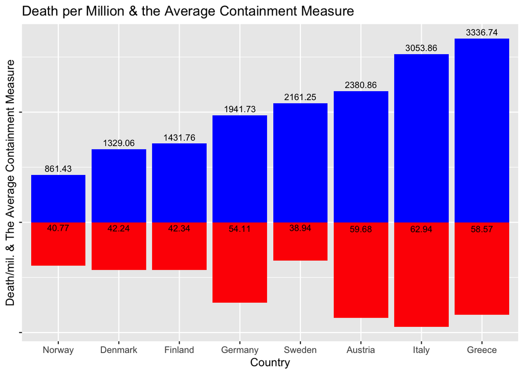

```r
 Lo_Hi_by_country %>%
  ggplot() +
  geom_bar(aes(x = reorder(Country_Region, death_per_million), y = death_per_million),
           stat = "identity", fill = "blue") +
  geom_bar(aes(x = reorder(Country_Region, containment), y = -(containment - 25) * 50),
           stat = "identity", fill = "red") +
  labs(title = "Death per Million & the Average Containment Measure",
       x = "Country", y = "Death/mil. & The Average Containment Measure") +
  theme(axis.text.y = element_blank()) +  # Hide y-axis text
  geom_text(aes(x = reorder(Country_Region, death_per_million),
                y = death_per_million,
                label = round(death_per_million, 2)),
            vjust = -0.5, color = "black", size = 3) +
  geom_text(aes(x = reorder(Country_Region, containment),
                y = -containment,
                label = round(containment, 2)),
            vjust = 1, color = "black", size = 3)
```

When examining the death rates per million in relation to containment measures, it becomes apparent that stricter measures do not necessarily lead to lower mortality rates. For instance, analyzing Norway reveals that despite having comparatively lenient containment measures, the country boasts remarkably low mortality rates. Conversely, Greece, despite implementing stringent containment measures, faces challenges with respect to mortality rates.

This dichotomy indicates that additional factors beyond containment measures influence these outcomes. Factors such as vaccination rates, the age distribution of the population, and overall population adherence to guidelines likely play significant roles. It’s important to recognize that these observations are not exhaustive and other variables could be at play as well. To gain a comprehensive understanding, a multifaceted analysis that considers a wide array of factors is necessary.

## Evaluating the containment measure vs number of cases and death in Greece, and Norway.

### Norway cases vs Containment

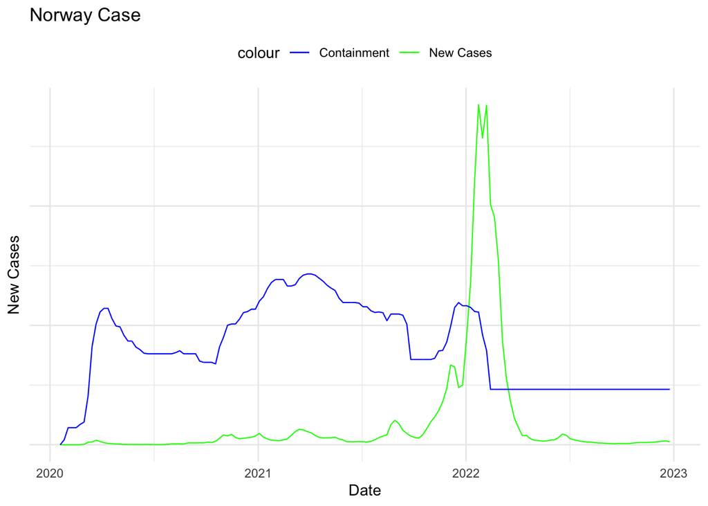

```r
ggplot(Norway_weekly, aes(x = week_start)) +
  geom_line(aes(y = weekly_new_cases, color = "New Cases"), linetype = "solid", linewidth = 0.4) +
  geom_line(aes(y = weekly_Containment * 1000, color = "Containment"), linetype = "solid", linewidth = 0.4) +
  labs(
    title = "Norway Case",
    x = "Date",
    y = "New Cases"
  ) +
  theme_minimal() +
  theme(axis.text.y = element_blank()) +
  scale_y_continuous(limits = c(0, NA)) +
  scale_color_manual(
    values = c("blue", "green"),
    labels = c("Containment", "New Cases")
  ) +
  scale_linetype_manual(
    values = "none",  # Remove linetype legend entries
    guide = guide_legend(override.aes = list(linetype = 0))
  ) +
  theme(legend.position = "top")
```

### Norway Death vs Containment

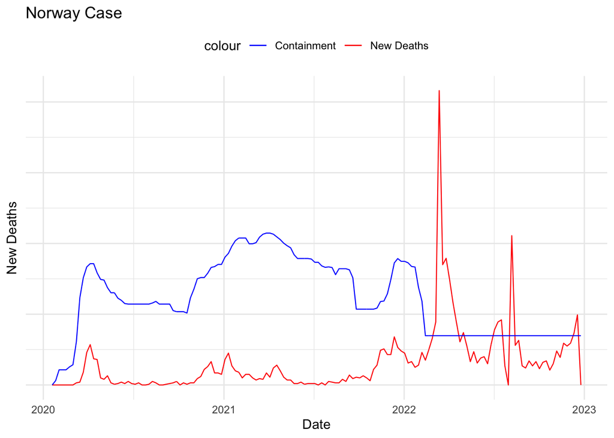

```r
ggplot(Norway_weekly, aes(x = week_start)) +
  geom_line(aes(y = weekly_new_deaths, color = "New Deaths"), linetype = "solid", linewidth = 0.4) +
  geom_line(aes(y = weekly_Containment*3, color = "Containment"), linetype = "solid", linewidth = 0.4) +
  labs(
    title = "Norway Case",
    x = "Date",
    y = "New Deaths"
  ) +
  theme_minimal() +
  theme(axis.text.y = element_blank()) +
  scale_y_continuous(limits = c(0, NA)) +

  scale_color_manual(
    values = c("blue", "red"),
    labels = c("Containment", "New Deaths")
  ) +
  scale_linetype_manual(
    values = "none",  # Remove linetype legend entries
    guide = guide_legend(override.aes = list(linetype = 0))
  ) +
  theme(legend.position = "top")
```

### Greece New Cases vs Containment

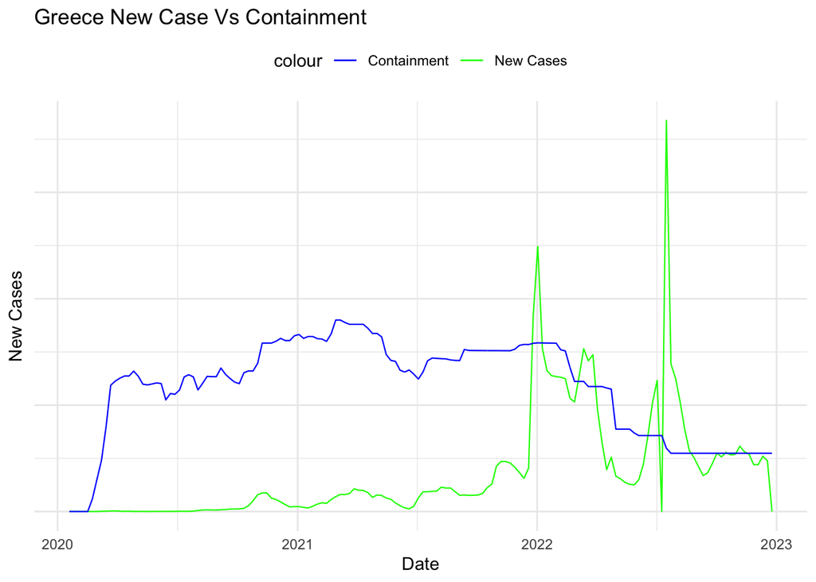

```r
ggplot(Greece_weekly, aes(x = week_start)) +
  geom_line(aes(y = weekly_new_cases, color = "New Cases"), linetype = "solid", linewidth = 0.4) +
  geom_line(aes(y = weekly_Containment*2000, color = "Containment"), linetype = "solid", linewidth = 0.4) +
  labs(
    title = "Greece New Case Vs Containment",
    x = "Date",
    y = "New Cases"
  ) +
  theme_minimal() +
  theme(axis.text.y = element_blank()) +
  scale_y_continuous(limits = c(0, NA)) +

  scale_color_manual(
    values = c("blue", "green"),
    labels = c("Containment", "New Cases")
  ) +
  scale_linetype_manual(
    values = "none",  # Remove linetype legend entries
    guide = guide_legend(override.aes = list(linetype = 0))
  ) +
  theme(legend.position = "top")
```

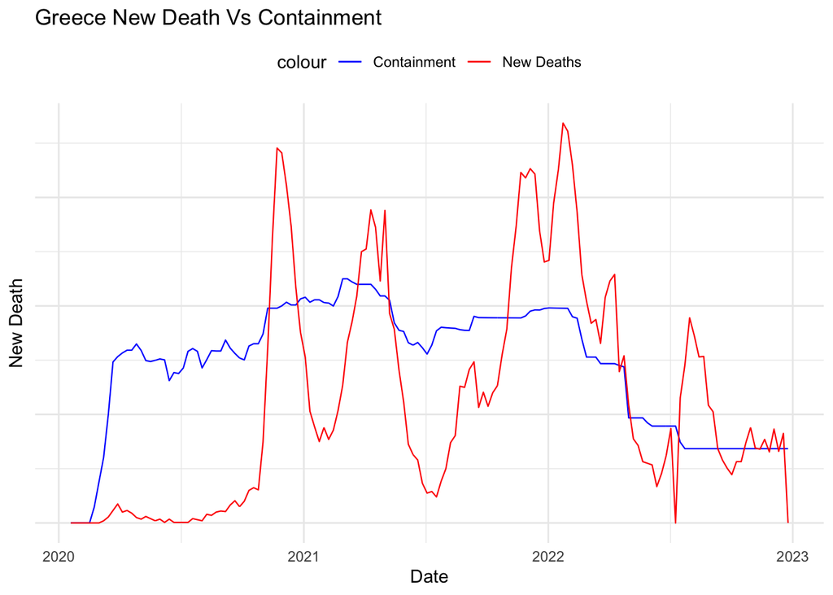

```r
ggplot(Greece_weekly, aes(x = week_start)) +
  geom_line(aes(y = weekly_Containment*5, color = "Containment"), linetype = "solid", linewidth = 0.4) +
  geom_line(aes(y = weekly_new_deaths, color = "New Deaths"), linetype = "solid", linewidth = 0.4) +
  labs(
    title = "Greece New Death Vs Containment",
    x = "Date",
    y = "New Death"
  ) +
  theme_minimal() +
  theme(axis.text.y = element_blank()) +
  scale_y_continuous(limits = c(0, NA)) +

  scale_color_manual(
    values = c("blue", "red"),
    labels = c("Containment", "New Deaths")
  ) +
  scale_linetype_manual(
    values = "none",  # Remove linetype legend entries
    guide = guide_legend(override.aes = list(linetype = 0))
  ) +
  theme(legend.position = "top")
```